# Differential gene expression with DESeq2

Barbara Vreede  
10 September 2018

### Studying gene expression

- Genes are the bits of DNA that encode proteins (building blocks)
- DNA -> RNA -> Protein
- Which genes are active?
- How much?
- Is there a difference in expression levels between contexts?

### RNAseq technology and output

- Next Generation Sequencing: rapid and affordable
- RNASeq: sequences RNA in a quantified manner
- Results are bits of sequences (~75bp) that need to be mapped to a genome

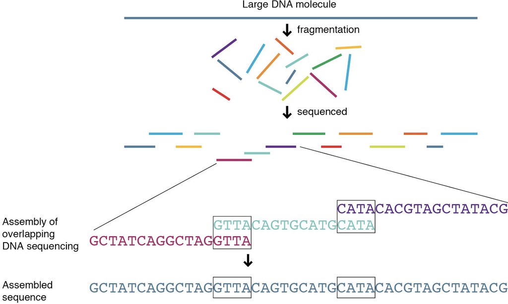

### Mapped reads are counted per gene

- Done with e.g. htseq
- Coverage is counted -> counts table

### A lot of this processing can be done in R!

(I didn't know this either!) [http://biocluster.ucr.edu/~rkaundal/workshops/R_mar2016/RNAseq.html](http://biocluster.ucr.edu/%7Erkaundal/workshops/R_mar2016/RNAseq.html)

### Analysing and comparing expression levels

- Various tools available
- Well known, powerful, easy to use (and in R!): edgeR and DESeq
- DESeq takes into account absolute expression level in variance calculations
- Written by Michael Love, Simon Anders, Wolfgang Huber (Genome Biol, 2014)

### DESeq2 input

- Counts table
- Study design

### Counts table

|  | FC_S61 | FC_S62 | FC_S63 | FD_S52 | FD_S53 | FD_S54 | MC_S67 | MC_S68 | MC_S69 | MD_S56 | MD_S57 | MD_S58 |
| --- | --- | --- | --- | --- | --- | --- | --- | --- | --- | --- | --- | --- |
| OTAU000001 | 0 | 0 | 2 | 1 | 1 | 1 | 0 | 0 | 0 | 0 | 1 | 0 |
| OTAU000002 | 358 | 690 | 440 | 1348 | 458 | 900 | 758 | 867 | 674 | 1118 | 648 | 355 |
| OTAU000003 | 415 | 1032 | 631 | 1829 | 546 | 1479 | 1155 | 1297 | 1104 | 1586 | 871 | 497 |
| OTAU000004 | 1 | 0 | 0 | 0 | 1 | 1 | 0 | 0 | 1 | 0 | 0 | 2 |
| OTAU000005 | 7 | 17 | 8 | 35 | 9 | 27 | 12 | 18 | 14 | 14 | 10 | 6 |
| OTAU000006 | 5 | 6 | 5 | 48 | 5 | 76 | 23 | 58 | 5 | 12 | 5 | 3 |
| OTAU000007 | 0 | 3 | 1 | 2 | 4 | 0 | 0 | 0 | 4 | 2 | 1 | 2 |
| OTAU000008 | 614 | 1350 | 886 | 2875 | 842 | 1840 | 1378 | 1613 | 1288 | 2048 | 1379 | 647 |
| OTAU000009 | 427 | 148 | 127 | 143 | 459 | 202 | 125 | 178 | 158 | 67 | 67 | 523 |
| OTAU000010 | 1 | 1 | 2 | 2 | 1 | 3 | 2 | 3 | 1 | 1 | 0 | 1 |

### Study design

|  | sex | treatment |
| --- | --- | --- |
| FC_S61 | female | ctrl |
| FC_S62 | female | ctrl |
| FC_S63 | female | ctrl |
| FD_S52 | female | dsx |
| FD_S53 | female | dsx |
| FD_S54 | female | dsx |
| MC_S67 | male | ctrl |
| MC_S68 | male | ctrl |
| MC_S69 | male | ctrl |
| MD_S56 | male | dsx |
| MD_S57 | male | dsx |
| MD_S58 | male | dsx |

### Prepare the analysis

```r
counts <- read.table(
  "20180910_deseq2_counts.csv",
  header=T,
  sep=',',
  row.names=1)

design <- read.table(
  "20180910_deseq2_design.csv",
  header=T,
  sep=',',
  row.names=1)
```

### Run DESeq to make a DESeq dataset

- countData: the counts table
- colData: your study design
- design: a linear model (difference between treatment, controlling for sex)

```r
# apply DESeq
dds <- DESeqDataSetFromMatrix(
  countData=counts,
  colData=design,
  design=~sex+treatment)

dds <- DESeq(dds)

# filter low read counts
dds <- dds[ rowSums(counts(dds)) > 1, ]
```

### Differential expression analysis

```r
alpha <- 0.05
res <- results(dds, alpha = alpha)

res
```

```
log2 fold change (MLE): treatment dsx vs ctrl
Wald test p-value: treatment dsx vs ctrl
DataFrame with 13919 rows and 6 columns
               baseMean log2FoldChange     lfcSE        stat     pvalue
              <numeric>      <numeric> <numeric>   <numeric>  <numeric>
OTAU000001    0.5344967    0.430398581 1.7876363  0.24076406  0.8097380
OTAU000002  661.6809804    0.008142611 0.1173159  0.06940757  0.9446652
OTAU000003  946.2511921   -0.053034099 0.1634142 -0.32453781  0.7455309
OTAU000004    0.6331219    0.936391646 1.8357766  0.51007932  0.6099959
OTAU000005   13.1602888   -0.013815419 0.3033823 -0.04553798  0.9636785
...                 ...            ...       ...         ...        ...
OTAU017474    1.8692299     -0.6234889 1.1837745  -0.5266957 0.59840494
OTAU017477 1072.7750120      0.6556193 0.6623024   0.9899093 0.32221845
OTAU017479   30.4310788     -0.1993417 0.3301910  -0.6037164 0.54603222
OTAU017481    0.7217882     -0.8156595 1.3717362  -0.5946183 0.55209862
OTAU017482   53.6818183     -3.8175667 1.7595014  -2.1696867 0.03003059
                padj
           <numeric>
OTAU000001 0.9998366
OTAU000002 0.9998366
OTAU000003 0.9998366
OTAU000004 0.9998366
OTAU000005 0.9998366
...              ...
OTAU017474 0.9998366
OTAU017477 0.9998366
OTAU017479 0.9998366
OTAU017481 0.9998366
OTAU017482 0.9998366
```

### Fold Change

- log2 fold change: **A** vs **B**
- if log2FoldChange > 0: A is higher
- if log2FoldChange < 0: B is higher

```r
head(res)
```

```
log2 fold change (MLE): treatment dsx vs ctrl
Wald test p-value: treatment dsx vs ctrl
DataFrame with 6 rows and 6 columns
              baseMean log2FoldChange     lfcSE        stat    pvalue
             <numeric>      <numeric> <numeric>   <numeric> <numeric>
OTAU000001   0.5344967    0.430398581 1.7876363  0.24076406 0.8097380
OTAU000002 661.6809804    0.008142611 0.1173159  0.06940757 0.9446652
OTAU000003 946.2511921   -0.053034099 0.1634142 -0.32453781 0.7455309
OTAU000004   0.6331219    0.936391646 1.8357766  0.51007932 0.6099959
OTAU000005  13.1602888   -0.013815419 0.3033823 -0.04553798 0.9636785
OTAU000006  16.8356347    0.019243993 0.8005193  0.02403939 0.9808212
                padj
           <numeric>
OTAU000001 0.9998366
OTAU000002 0.9998366
OTAU000003 0.9998366
OTAU000004 0.9998366
OTAU000005 0.9998366
OTAU000006 0.9998366
```

```r
# significant p values
res.sig <- res[res$padj<alpha & is.na(res$padj)==F,]

# DSX-RNAi expression increased (DSX downregulates)
res.sig.dsx <- res.sig[res.sig$log2FoldChange > 0,]

# CTRL-RNAi expression increased (DSX upregulates)
res.sig.ctrl <- res.sig[res.sig$log2FoldChange < 0,]
```

### But what if I want to compare sexes?

|  | sex | treatment |
| --- | --- | --- |
| FC_S61 | female | ctrl |
| FC_S62 | female | ctrl |
| FC_S63 | female | ctrl |
| FD_S52 | female | dsx |
| FD_S53 | female | dsx |
| FD_S54 | female | dsx |
| MC_S67 | male | ctrl |
| MC_S68 | male | ctrl |
| MC_S69 | male | ctrl |
| MD_S56 | male | dsx |
| MD_S57 | male | dsx |
| MD_S58 | male | dsx |

### Add a 'group' variable

```r
design$group <- paste0(design$sex,design$treatment)

design
```

```
          sex treatment      group
FC_S61 female      ctrl femalectrl
FC_S62 female      ctrl femalectrl
FC_S63 female      ctrl femalectrl
FD_S52 female       dsx  femaledsx
FD_S53 female       dsx  femaledsx
FD_S54 female       dsx  femaledsx
MC_S67   male      ctrl   malectrl
MC_S68   male      ctrl   malectrl
MC_S69   male      ctrl   malectrl
MD_S56   male       dsx    maledsx
MD_S57   male       dsx    maledsx
MD_S58   male       dsx    maledsx
```

### New DESeq analysis with group variable

```r
# Apply DESeq
dds.group <- DESeqDataSetFromMatrix(
  countData=counts,
  colData=design,
  design=~group)

dds.group <- DESeq(dds.group)
dds.group <- dds.group[ rowSums(counts(dds.group)) > 1, ]

# Extract results: for males and females
res.male <- results(dds.group, contrast=c("group","malectrl","maledsx"), alpha=alpha)
res.female <- results(dds.group, contrast=c("group","femalectrl","femaledsx"), alpha=alpha)
```

### Males vs females

```r
# extract significant results
res.male.sig <- res.male[res.male$padj<alpha & is.na(res.male$padj)==F,]
res.female.sig <- res.female[res.female$padj<alpha & is.na(res.female$padj)==F,]
```

### Males vs females

```r
# what are the significantly differently expressed genes?
row.names(res.male.sig)
```

```
 [1] "OTAU001130" "OTAU001133" "OTAU001190" "OTAU001448" "OTAU003780"
 [6] "OTAU003845" "OTAU003846" "OTAU003847" "OTAU003896" "OTAU004508"
[11] "OTAU004900" "OTAU004901" "OTAU008694" "OTAU011126" "OTAU015392"
[16] "OTAU016038" "OTAU016533"
```

```r
row.names(res.female.sig)
```

```
[1] "OTAU000574" "OTAU002552" "OTAU003501" "OTAU009738" "OTAU010231"
[6] "OTAU010233" "OTAU012504" "OTAU017482"
```

```r
row.names(res.sig)
```

```
[1] "OTAU010231"
```

### Males vs females

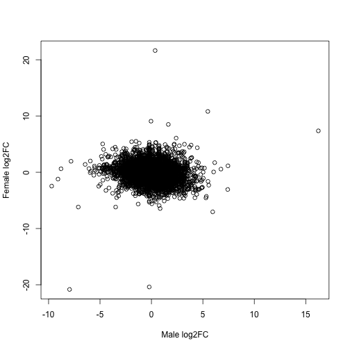

```r
# just for kicks: log2FC
plot(res.male$log2FoldChange,res.female$log2FoldChange, ylab = "Female log2FC", xlab="Male log2FC")
```

### Comparing samples

- Counts tables are absolute values
- Normalizing for sequencing depth is needed for comparisons
- Gene length required “official” values (RPKM, FPKM, TPM…)
- But, quick and dirty…

```r
# normalize and transform
nt <- normTransform(dds)
assay(nt)
```

[output not shown]

[output cut: 16614 more lines]

[output not shown]

### Comparing samples

```
              FC_S61     FC_S62    FC_S63     FD_S52
OTAU000001  0.000000  0.0000000  1.940890  0.5841789
OTAU000002  9.228353  9.3601960  9.289266  9.3963950
OTAU000003  9.441175  9.9402430  9.808704  9.8360665
OTAU000004  1.418268  0.0000000  0.000000  0.0000000
OTAU000005  3.667723  4.1015936  3.627338  4.2072284
OTAU000006  3.227005  2.7454774  3.017665  4.6415982
OTAU000007  0.000000  1.9460039  1.274835  0.9988244
OTAU000008 10.005629 10.3274135 10.297908 10.4879990
OTAU000009  9.482241  7.1472137  7.502262  6.1775894
OTAU000010  1.418268  0.9642281  1.940890  0.9988244
```

```
           FC_S61 FC_S62 FC_S63 FD_S52
OTAU000001      0      0      2      1
OTAU000002    358    690    440   1348
OTAU000003    415   1032    631   1829
OTAU000004      1      0      0      0
OTAU000005      7     17      8     35
OTAU000006      5      6      5     48
OTAU000007      0      3      1      2
OTAU000008    614   1350    886   2875
OTAU000009    427    148    127    143
OTAU000010      1      1      2      2
```

### Comparing samples

```r
# select 20 samples for the heatmap
select <- order(rowMeans(counts(dds,normalized=TRUE)),decreasing=TRUE)[1:20]
log2.norm.counts <- assay(nt)[select,]
```

[output not shown]

### Let's discuss!

[output not shown]